# About the Data

Data on Titanic passengers

The dataset contains information about the passengers of the RMS Titanic, which sank on April 15, 1912, after colliding with an iceberg. The data includes attributes such as travel class, age, gender, number of siblings/spouses on board, number of parents/children on board, ticket fare, and port of embarkation.

The dataset also includes information on whether a passenger survived the disaster.

The Titanic carried more than 2,200 people, of which over 1,500 died, making this disaster one of the most tragic in maritime history.

Columns:

- **pclass** - Ticket class
- **survived** - Whether the passenger survived the disaster
- **name** - Passenger's full name
- **sex** - Passenger's gender
- **age** - Passenger's age
- **sibsp** - Number of siblings/spouses aboard
- **parch** - Number of parents/children aboard
- **ticket** - Ticket number
- **fare** - Ticket fare
- **cabin** - Cabin number
- **embarked** - Port of embarkation (C = Cherbourg, Q = Queenstown, S = Southampton)
- **boat** - Lifeboat number
- **body** - Body number (if the passenger did not survive and the body was recovered)
- **home.dest** - Destination

|  | pclass | survived | name | sex | age | sibsp | parch | ticket | fare | cabin | embarked | boat | body | home.dest |
| --- | --- | --- | --- | --- | --- | --- | --- | --- | --- | --- | --- | --- | --- | --- |
| 0 | 1.0 | 1.0 | Allen, Miss. Elisabeth Walton | female | 29.0000 | 0.0 | 0.0 | 24160 | 211.3375 | B5 | S | 2 | NaN | St Louis, MO |
| 1 | 1.0 | 1.0 | Allison, Master. Hudson Trevor | male | 0.9167 | 1.0 | 2.0 | 113781 | 151.5500 | C22 C26 | S | 11 | NaN | Montreal, PQ / Chesterville, ON |
| 2 | 1.0 | 0.0 | Allison, Miss. Helen Loraine | female | 2.0000 | 1.0 | 2.0 | 113781 | 151.5500 | C22 C26 | S | NaN | NaN | Montreal, PQ / Chesterville, ON |
| 3 | 1.0 | 0.0 | Allison, Mr. Hudson Joshua Creighton | male | 30.0000 | 1.0 | 2.0 | 113781 | 151.5500 | C22 C26 | S | NaN | 135.0 | Montreal, PQ / Chesterville, ON |
| 4 | 1.0 | 0.0 | Allison, Mrs. Hudson J C (Bessie Waldo Daniels) | female | 25.0000 | 1.0 | 2.0 | 113781 | 151.5500 | C22 C26 | S | NaN | NaN | Montreal, PQ / Chesterville, ON |
| ... | ... | ... | ... | ... | ... | ... | ... | ... | ... | ... | ... | ... | ... | ... |
| 1305 | 3.0 | 0.0 | Zabour, Miss. Thamine | female | NaN | 1.0 | 0.0 | 2665 | 14.4542 | NaN | C | NaN | NaN | NaN |
| 1306 | 3.0 | 0.0 | Zakarian, Mr. Mapriededer | male | 26.5000 | 0.0 | 0.0 | 2656 | 7.2250 | NaN | C | NaN | 304.0 | NaN |
| 1307 | 3.0 | 0.0 | Zakarian, Mr. Ortin | male | 27.0000 | 0.0 | 0.0 | 2670 | 7.2250 | NaN | C | NaN | NaN | NaN |
| 1308 | 3.0 | 0.0 | Zimmerman, Mr. Leo | male | 29.0000 | 0.0 | 0.0 | 315082 | 7.8750 | NaN | S | NaN | NaN | NaN |
| 1309 | NaN | NaN | NaN | NaN | NaN | NaN | NaN | NaN | NaN | NaN | NaN | NaN | NaN | NaN |

1310 rows × 14 columns

# General Overview of the Data

|  | pclass | survived | name | sex | age | sibsp | parch | ticket | fare | cabin | embarked | boat | body | home.dest |
| --- | --- | --- | --- | --- | --- | --- | --- | --- | --- | --- | --- | --- | --- | --- |
| 485 | 2.0 | 0.0 | Levy, Mr. Rene Jacques | male | 36.0 | 0.0 | 0.0 | SC/Paris 2163 | 12.8750 | D | C | NaN | NaN | Montreal, PQ |
| 336 | 2.0 | 1.0 | Beane, Mr. Edward | male | 32.0 | 1.0 | 0.0 | 2908 | 26.0000 | NaN | S | 13 | NaN | Norwich / New York, NY |
| 303 | 1.0 | 0.0 | Warren, Mr. Frank Manley | male | 64.0 | 1.0 | 0.0 | 110813 | 75.2500 | D37 | C | NaN | NaN | Portland, OR |
| 701 | 3.0 | 0.0 | Calic, Mr. Petar | male | 17.0 | 0.0 | 0.0 | 315086 | 8.6625 | NaN | S | NaN | NaN | NaN |
| 1123 | 3.0 | 1.0 | Peter, Mrs. Catherine (Catherine Rizk) | female | NaN | 0.0 | 2.0 | 2668 | 22.3583 | NaN | C | D | NaN | NaN |
| 824 | 3.0 | 0.0 | Goncalves, Mr. Manuel Estanslas | male | 38.0 | 0.0 | 0.0 | SOTON/O.Q. 3101306 | 7.0500 | NaN | S | NaN | NaN | Portugal |
| 580 | 2.0 | 1.0 | Ware, Mrs. John James (Florence Louise Long) | female | 31.0 | 0.0 | 0.0 | CA 31352 | 21.0000 | NaN | S | 10 | NaN | Bristol, England / New Britain, CT |
| 272 | 1.0 | 1.0 | Snyder, Mrs. John Pillsbury (Nelle Stevenson) | female | 23.0 | 1.0 | 0.0 | 21228 | 82.2667 | B45 | S | 7 | NaN | Minneapolis, MN |
| 457 | 2.0 | 0.0 | Hunt, Mr. George Henry | male | 33.0 | 0.0 | 0.0 | SCO/W 1585 | 12.2750 | NaN | S | NaN | NaN | Philadelphia, PA |
| 675 | 3.0 | 0.0 | Birkeland, Mr. Hans Martin Monsen | male | 21.0 | 0.0 | 0.0 | 312992 | 7.7750 | NaN | S | NaN | NaN | Brennes, Norway New York |
| 3 | 1.0 | 0.0 | Allison, Mr. Hudson Joshua Creighton | male | 30.0 | 1.0 | 2.0 | 113781 | 151.5500 | C22 C26 | S | NaN | 135.0 | Montreal, PQ / Chesterville, ON |
| 663 | 3.0 | 0.0 | Balkic, Mr. Cerin | male | 26.0 | 0.0 | 0.0 | 349248 | 7.8958 | NaN | S | NaN | NaN | NaN |
| 1013 | 3.0 | 0.0 | Meanwell, Miss. (Marion Ogden) | female | NaN | 0.0 | 0.0 | SOTON/O.Q. 392087 | 8.0500 | NaN | S | NaN | NaN | NaN |
| 35 | 1.0 | 1.0 | Bowen, Miss. Grace Scott | female | 45.0 | 0.0 | 0.0 | PC 17608 | 262.3750 | NaN | C | 4 | NaN | Cooperstown, NY |
| 21 | 1.0 | 1.0 | Beckwith, Mrs. Richard Leonard (Sallie Monypeny) | female | 47.0 | 1.0 | 1.0 | 11751 | 52.5542 | D35 | S | 5 | NaN | New York, NY |
| 1177 | 3.0 | 0.0 | Sage, Mr. Frederick | male | NaN | 8.0 | 2.0 | CA. 2343 | 69.5500 | NaN | S | NaN | NaN | NaN |
| 737 | 3.0 | 0.0 | Crease, Mr. Ernest James | male | 19.0 | 0.0 | 0.0 | S.P. 3464 | 8.1583 | NaN | S | NaN | NaN | Bristol, England Cleveland, OH |
| 665 | 3.0 | 0.0 | Barbara, Miss. Saiide | female | 18.0 | 0.0 | 1.0 | 2691 | 14.4542 | NaN | C | NaN | NaN | Syria Ottawa, ON |
| 1153 | 3.0 | 0.0 | Robins, Mrs. Alexander A (Grace Charity Laury) | female | 47.0 | 1.0 | 0.0 | A/5. 3337 | 14.5000 | NaN | S | NaN | 7.0 | NaN |
| 95 | 1.0 | 1.0 | Dodge, Mrs. Washington (Ruth Vidaver) | female | 54.0 | 1.0 | 1.0 | 33638 | 81.8583 | A34 | S | 5 | NaN | San Francisco, CA |

```
pclass          3
survived        2
name         1307
sex             2
age            98
sibsp           7
parch           8
ticket        929
fare          281
cabin         186
embarked        3
boat           27
body          121
home.dest     369
dtype: int64
```

|  | pclass | survived | age | sibsp | parch | fare | body |
| --- | --- | --- | --- | --- | --- | --- | --- |
| count | 1309.000000 | 1309.000000 | 1046.000000 | 1309.000000 | 1309.000000 | 1308.000000 | 121.000000 |
| mean | 2.294882 | 0.381971 | 29.881135 | 0.498854 | 0.385027 | 33.295479 | 160.809917 |
| std | 0.837836 | 0.486055 | 14.413500 | 1.041658 | 0.865560 | 51.758668 | 97.696922 |
| min | 1.000000 | 0.000000 | 0.166700 | 0.000000 | 0.000000 | 0.000000 | 1.000000 |
| 25% | 2.000000 | 0.000000 | 21.000000 | 0.000000 | 0.000000 | 7.895800 | 72.000000 |
| 50% | 3.000000 | 0.000000 | 28.000000 | 0.000000 | 0.000000 | 14.454200 | 155.000000 |
| 75% | 3.000000 | 1.000000 | 39.000000 | 1.000000 | 0.000000 | 31.275000 | 256.000000 |
| max | 3.000000 | 1.000000 | 80.000000 | 8.000000 | 9.000000 | 512.329200 | 328.000000 |

From the initial analysis, it is clear that passengers were very diverse in terms of class, age, gender, and the price paid for the ticket. It is possible that these differences had a significant impact on the survival rate of individuals.

There are only 1,310 entries, while there were over 2,200 passengers, which already makes the data incomplete. However, even with this amount of information, many trends can still be observed.

# Missing Values

```
pclass          1
survived        1
name            1
sex             1
age           264
sibsp           1
parch           1
ticket          1
fare            2
cabin        1015
embarked        3
boat          824
body         1189
home.dest     565
dtype: int64
```

|  | pclass | survived | name | sex | age | sibsp | parch | ticket | fare | cabin | embarked | boat | body | home.dest |
| --- | --- | --- | --- | --- | --- | --- | --- | --- | --- | --- | --- | --- | --- | --- |
| 0 | False | False | False | False | False | False | False | False | False | False | False | False | True | False |
| 1 | False | False | False | False | False | False | False | False | False | False | False | False | True | False |
| 2 | False | False | False | False | False | False | False | False | False | False | False | True | True | False |
| 3 | False | False | False | False | False | False | False | False | False | False | False | True | False | False |
| 4 | False | False | False | False | False | False | False | False | False | False | False | True | True | False |
| ... | ... | ... | ... | ... | ... | ... | ... | ... | ... | ... | ... | ... | ... | ... |
| 1305 | False | False | False | False | True | False | False | False | False | True | False | True | True | True |
| 1306 | False | False | False | False | False | False | False | False | False | True | False | True | False | True |
| 1307 | False | False | False | False | False | False | False | False | False | True | False | True | True | True |
| 1308 | False | False | False | False | False | False | False | False | False | True | False | True | True | True |
| 1309 | True | True | True | True | True | True | True | True | True | True | True | True | True | True |

1310 rows × 14 columns

Most passengers do not have a recorded body number. This could mean two things:

- most passengers survived the disaster

  *or*
- a huge number of bodies were never recovered

It is also visible that as many as 824 passengers do not have a lifeboat number assigned, which makes the second theory much more likely.

The rest of the missing values can be explained by the destruction and chaos caused by the disaster. Things like documents with cabin numbers most likely were destroyed.

Interestingly, there is one entry missing all values. Perhaps this was an error, or one of the passengers was listed but never actually boarded. This entry is not useful for analysis and can be removed.

# Detailed Information About Passengers

## Passenger Class

```
pclass
3.0    709
1.0    323
2.0    277
Name: count, dtype: int64
```

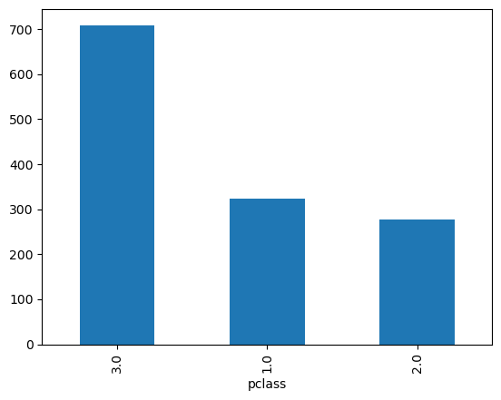

## Survival

```
survived
0.0    809
1.0    500
Name: count, dtype: int64
```

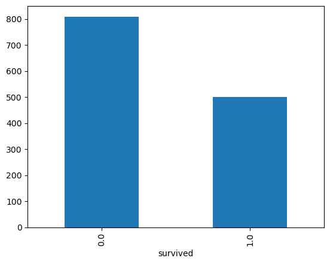

## Gender

```
sex
male      843
female    466
Name: count, dtype: int64
```

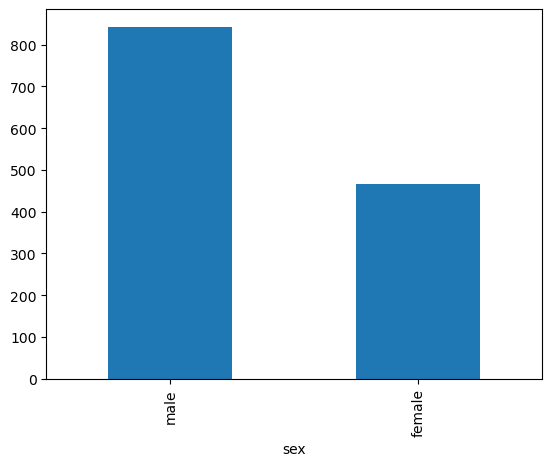

## Number of people with spouse and/or siblings

```
sibsp
0.0    891
1.0    319
2.0     42
4.0     22
3.0     20
8.0      9
5.0      6
Name: count, dtype: int64
```

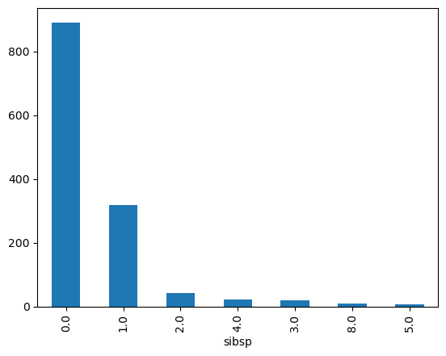

## Number of people with parents and/or children

```
parch
0.0    1002
1.0     170
2.0     113
3.0       8
4.0       6
5.0       6
6.0       2
9.0       2
Name: count, dtype: int64
```

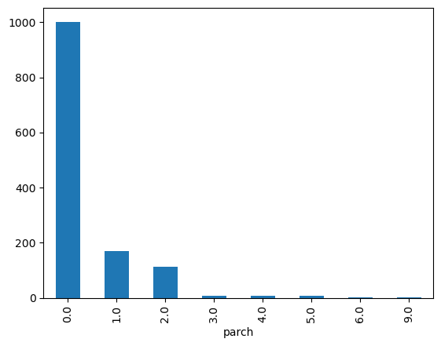

## Port of embarkation

```
embarked
S    914
C    270
Q    123
Name: count, dtype: int64
```

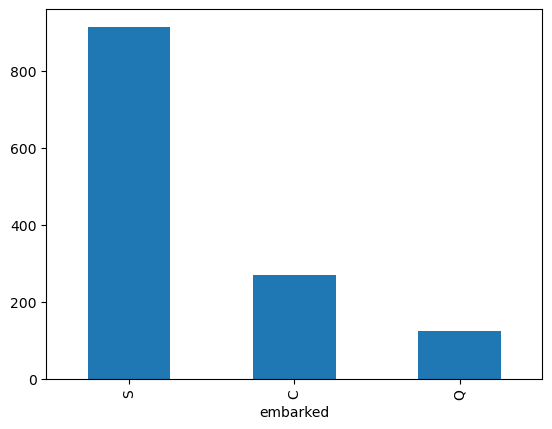

## Children

```
107
```

## Adults and youth

```
937
```

## Ticket prices per class

```
pclass
3.0    689
2.0    265
1.0    114
Name: count, dtype: int64
```

```
pclass
1.0    209
3.0     19
2.0     12
Name: count, dtype: int64
```

```
pclass
1.0    17
Name: count, dtype: int64
```

## Single people

```
sibsp
0.0    790
Name: count, dtype: int64
```

## Passenger Information

**Class, where 3.0 means the poorest and 1.0 the wealthiest**: 3.0 - 709 2.0 - 277 1.0 - 323

**Gender**: Male - 843 Female - 466

There were **107 children** aboard There were **937 adults and youth** aboard

People without family aboard - 790

Port of embarkation (C = Cherbourg, Q = Queenstown, S = Southampton): Southampton = 914 Cherbourg = 270 Queenstown = 123

**809 people died 500 people survived**

# Correlations

1. Correlation between:
- gender and survival
- class and survival
- family and survival
- age and survival

## Gender and survival

```
sex
female    339
male      161
Name: count, dtype: int64
```

```
sex
male      682
female    127
Name: count, dtype: int64
```

Died:

- 682 men
- 127 women

Survived:

- 161 men
- 339 women

It is clear that women had a much higher chance of survival.

## Class and survival

```
pclass
1.0    200
3.0    181
2.0    119
Name: count, dtype: int64
```

```
3.0    528
2.0    158
1.0    123
Name: pclass, dtype: int64
```

Survived:

- 200 from 1st class
- 119 from 2nd class
- 181 from 3rd class

It is evident that the wealthier the passenger, the higher their chance of survival.

## Age and survival

```
1.0    61
0.0    46
Name: survived, dtype: int64
```

```
survived
0.0    571
1.0    366
Name: count, dtype: int64
```

Considering proportion children had higher chance of survival.

## Ticket fare and survival

```
0.0    726
1.0    342
Name: survived, dtype: int64
```

```
1.0    158
0.0     82
Name: survived, dtype: int64
```

```
1.0    14
0.0     3
Name: survived, dtype: int64
```

The wealthiest had the highest chance of survival.

## Conclusions

- Women had a higher chance of survival than men
- Nearly all the wealthiest survived
- Most of the poor perished
- Children had a much better chance of survival, especially compared to adults and youth